# Geochronological principles and methods

Dr. Ahmad Redaa

2024-09-10

# What is Geochronology?

- Geochronology is the science of determining the age of rocks and minerals.
- This branch of geosciences helps us understand Earth’s history, geological events, and the timing of processes.

# Fundamental Principles of Geochronology

## A. Radiometric Dating

- Based on radioactive decay of isotopes.
- Common isotopes: Rb-Sr, U-Pb, K-Ar.

## B. Assumptions in Radiometric Dating

- Closed system behavior.
- Known initial conditions and isotopic ratios.

# Geochronological Methods

## A. U-Pb Dating

- Utilizes the decay of U isotopes to Pb.
- Application: Dating zircon, apatite and carbonate.

## B. Rb-Sr Dating

- Based on Rb isotopes decaying to Sr.
- Useful for dating igneous and metamorphic rocks.

## C. K-Ar and Ar-Ar Dating

- Relays on measuring the ratio of K to Ar.
- Use: Dating volcanic rocks and understanding eruption timing.

## D. Fission track dating

- Based on the spontaneous fission of uranium-238 isotopes within minerals.
- Commonly applied to apatite and zircon.
- As uranium fissions, it creates damage tracks in the crystal structure of the mineral, which can be counted.
- This method can help reconstruct the thermal history of geological formations by analyzing the number and length of fission tracks in a mineral sample.

# Isochron Diagram

- An isochron diagram represents the relationship between the ratios of parent and daughter isotopes in a system that has remained closed since its formation.

# Calculation of Isochron Line (con.)

- Assume we have five samples containing parent (radioactive isotope) and daughter (radiogenic isotope) atoms, as shown in the table below:

| Sample | Parent Atoms | Daughter Atoms |
| --- | --- | --- |
| 1 | 1000 | 100 |
| 2 | 800 | 100 |
| 3 | 600 | 100 |
| 4 | 400 | 100 |
| 5 | 100 | 100 |

- After some time, we analyze the samples, and the results are as follows:

| Sample | Parent Atoms | Daughter Atoms |
| --- | --- | --- |
| 1 | 900 | 200 |
| 2 | 720 | 180 |
| 3 | 540 | 160 |
| 4 | 360 | 140 |
| 5 | 90 | 110 |

# Calculation of Isochron Line (con.)

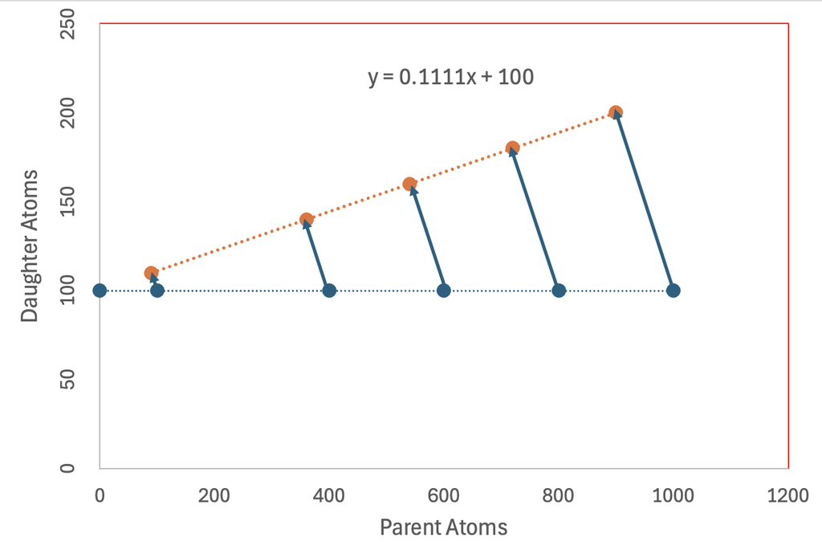

# Calculation of Isochron Line (con.)

## Line Equation

The equation of the isochron line can be represented as:

$$Y = b + Xm$$

Where:  
- $Y$ represents the amount of daughter isotope.  
- $X$ represents the amount of parent isotope.  
- $m$ is the slope of the isochron line, which is related to the age of the geological sample.  
- $b$ is the y-intercept, representing the initial condition of the daughter isotope at the time of formation.

- This equation is similar as the Radioactive Decay Equation:
  $$D = D_0 + n \left( e^{\lambda t} - 1 \right)$$

Where: - $D$ represents $Y$  
- $D_0$ represents $b$  
- $n$ represents $X$  
- $( e^{\lambda t} - 1)$ represents $m$

- We can solve for $t$:

$$t = \frac{\ln(\text{\(m\) } + 1)}{\lambda}$$

- We can also determain the initial amount of dughter atoms from y-intercept ($b$)

# Summary

- **Geochronology:** The science of determining the age of rocks and minerals, crucial for understanding Earth’s history and geological events.
- **Fundamental Principles:**
  - **Radiometric Dating:** Based on radioactive decay of isotopes (e.g., Rb-Sr, U-Pb, K-Ar).
  - **Key Assumptions:** Closed system behavior and known initial isotopic conditions.
- **Geochronological Methods:**
  - **U-Pb Dating:** Effective for dating zircon and understanding igneous/metamorphic processes.
  - **Rb-Sr Dating:** Useful for dating igneous and metamorphic rocks.
  - **K-Ar and Ar-Ar Dating:** Primarily for volcanic rocks, providing eruption timing insights.
  - **Fission Track Dating:** Based on uranium fission tracks in minerals like apatite and zircon.
- **Isochron Diagrams:** Illustrate relationships between parent and daughter isotopes, and determain the age through slope calculations.
- **Key Equations:**
  - Isochron Line: $Y = mX + b$
  - Age Calculation: $t = \frac{\ln(\text{slope} + 1)}{\lambda}$
- **Applications:** Understanding geological timelines, tectonic movements, and Earth’s climatic changes.